# Time Series Prediction - Considerations and Methods

Associate Professor Ole Maneesoonthorn

Predictive Analytics, Term 4 2020

This document includes all plots and analytics of the examples that we go through in Session 2 of Predictive Analytics.

## Time Series Data and Plots

For our exploration of time series, we will look at the Retail Sales (aggregate) time series of the US. Specifically we will focus on the beer, wine and liquor (BWL) category. The data is obtained from the St. Louis Federal Reserve (FRED) database.

The time series analytics tools that we use are from the “forecast” library. It is best to classify the data as a time series data type, as the modelling functions that we use recognize the characteristics of the time series through this definition.

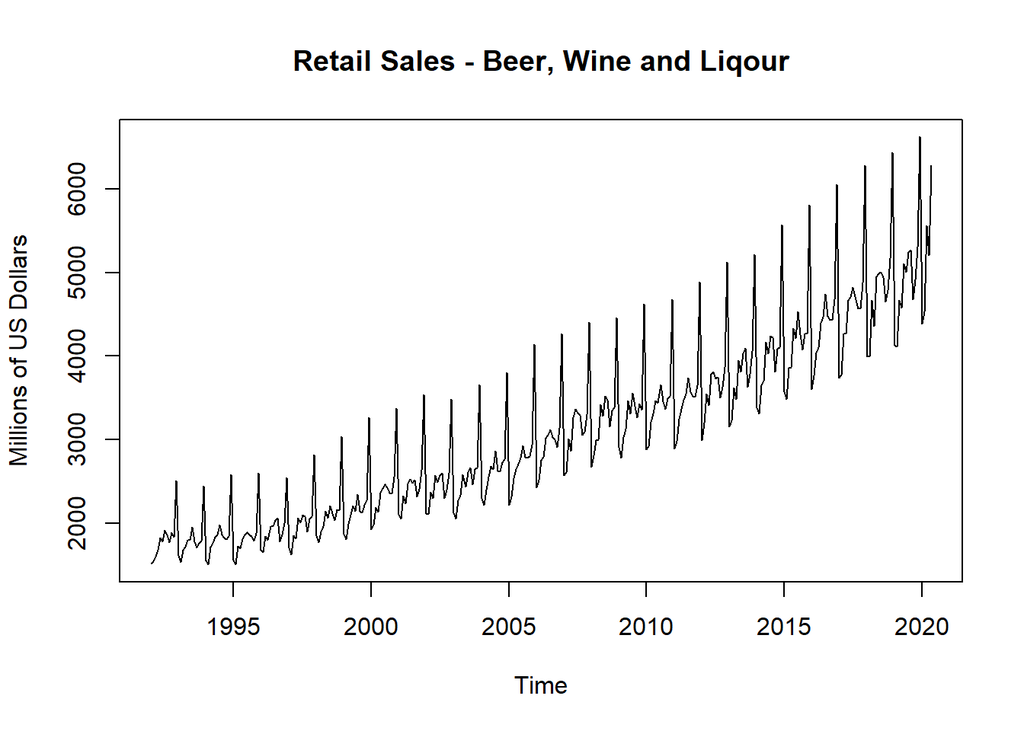

```r
library(forecast)
#Read in the data and classify it as a time series "ts" data type
#You can specify the start date and seasonal frequency of the data
bwl=ts(read.csv("RetailBWL.csv")[,2],start=c(1992,1),frequency=12)
#Plot the time series data and modify the title and label accordingly
plot(bwl,main="Retail Sales - Beer, Wine and Liqour",
     ylab="Millions of US Dollars")
```

## Seasonal Adjustments

As was discussed in class, one of the considerations for dealing with time series is whether to seasonally adjust the data. If seasonal adjustment is the path you wish to take, the Seasonal, Trend by Loess (STL) decomposition method is a flexible way to separate trend, seasonal and error components.

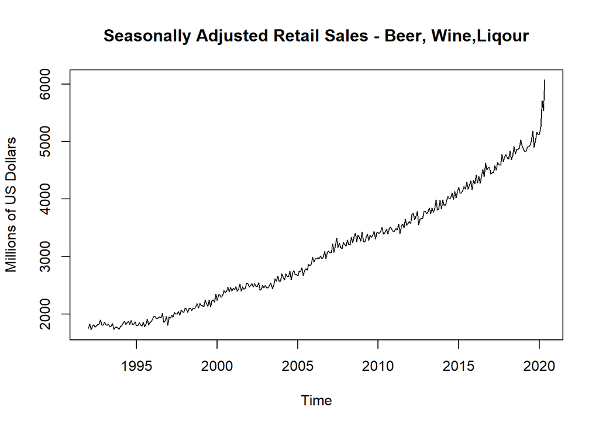

```r
#The stl() function for decomposition takes in two inputs
#s.window controls the smoothness of the seasonal component
#t.window controls the smoothness of the trend component
stl_bwl=stl(bwl,s.window=9,t.window=11)
#construct the seasonally adjusted series
bwl_sadj=seasadj(stl_bwl)
plot(bwl_sadj,main="Seasonally Adjusted Retail Sales - Beer, Wine,Liqour",
     ylab="Millions of US Dollars")
```

The seasonally adjusted data reveals an acceleration in the trend towards the end of the sample that was not visible in the raw data plot.

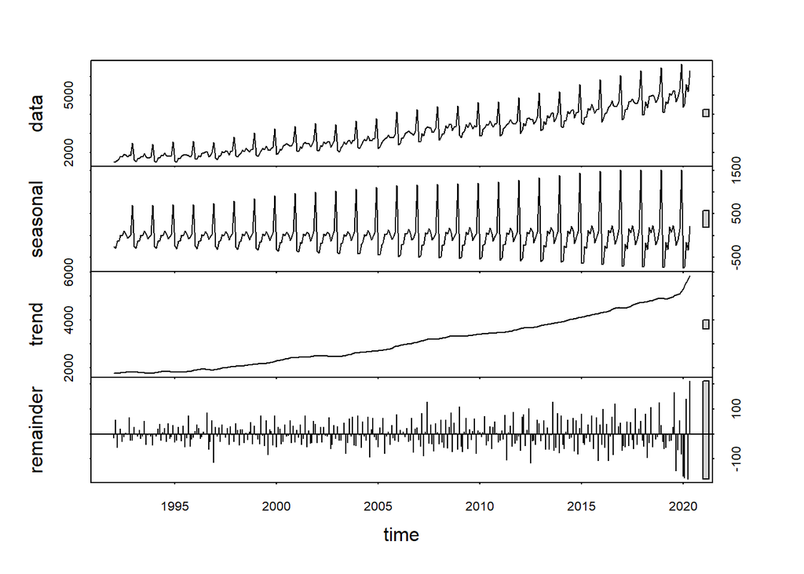

```r
#Plot the decomposition of the BWL data can also be useful
plot(stl_bwl)
```

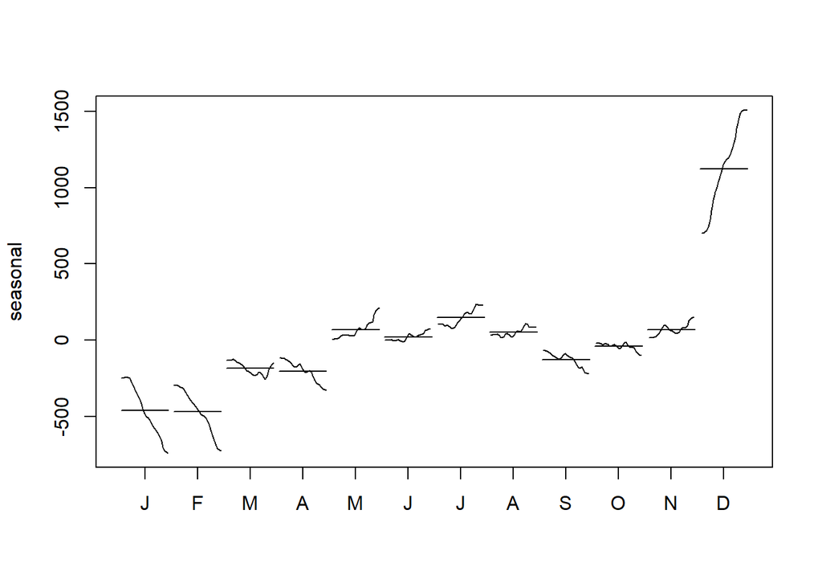

```r
#Plotting the trend of each seasonal component reveal a different angle
monthplot(stl_bwl)
```

Another feature that is more prominent is the change in seasonality over the sample period. The trough months are January and February, with the smallest amount of BWL sales relative to trend. Not surprisingly, the peak of the seasonality is in December, which coincide with the festive season of Christmas and the onset of the new year.

The “monthplot()” function provide a different perspective of the seasonality pattern. It gathers the movement of the seasonality, by month, across the years. We can see from this plot that the seasonality factor for the trough months (Jan and Feb) are decreasing over time, while the seasonality factor for the peak December month is increasing. These features contribute to the expanding magnitude of seasonal variations across the years.

## Prediction Methods

Let us now develop the predictive models for this BWL time series. We will explore the long-horizon predictions first, and consider real-time predictions later on in the document.

First, we will split the data into the training and test set. For this exploration, the training set is between Jan 1992 and Dec 2010. The test set is between Jan 2011 to May 2020. We will also declare a function that computes the accuracy metrics of time series forecasts for repeated calculations later.

```r
#Data split
bwl_train=window(bwl,end=c(2010,12))
bwl_test=window(bwl,start=c(2011,1))

#Function for accuracy metrics in time series data
tsaccuracy <- function (actual,predict) {
  stats<-matrix(0,1,5)
  colnames(stats)<-c("RMSE","MAE","MAPE","MASE","ACF")
  m=frequency(actual)
  actual=as.numeric(actual)
  dev<-actual-predict
  naive=c(rep(NA,m),actual[1:(length(actual)-m)])
  q<-dev/mean(abs(actual-naive),na.rm=TRUE)
  stats[1]=sqrt(mean(dev^2))
  stats[2]=mean(abs(dev))
  stats[3]=mean(100*abs(dev/actual))
  stats[4]=mean(abs(q))
  stats[5]=acf(dev,plot=FALSE)$acf[2]
  return(stats)
}
```

### Time Series Regression

The first model we consider is the time series regression model.

$$y_t=b_0+b_1t+b_2S_{2t}+b_3S_{3t}+...+b_{12}S_{12t}+e_t$$

With the data characterised as a time series data type with frequency $m=12$, we use the “tslm()” command to run a time series regression model. The advantage of this is that you can just specify that you want trend and seasonal components to be present, and the function will automatically construct the relevant trend and seasonal dummies. Remember that the function always leave the first season out as the reference.

To construct long-horizon predictions we use the “forecast()” function and pass in the regression model object. You also need to specify how far ahead you want to predict. In our case we predict $h=113$ periods into the future. The “plot()” function takes in the forecast object and will plot the predictions along with their prediction intervals.

```r
#Fit the linear regression with trend and seasonality
#Construct a summary
reg_bwl=tslm(bwl_train~trend+season)
summary(reg_bwl)
```

```
##
## Call:
## tslm(formula = bwl_train ~ trend + season)
##
## Residuals:
##     Min      1Q  Median      3Q     Max
## -443.69  -86.86  -21.58   70.38  365.92
##
## Coefficients:
##              Estimate Std. Error t value Pr(>|t|)
## (Intercept) 1182.0834    34.8093  33.959  < 2e-16 ***
## trend          8.2561     0.1379  59.872  < 2e-16 ***
## season2      -23.5193    44.4021  -0.530    0.597
## season3      183.2246    44.4027   4.126 5.27e-05 ***
## season4      198.7580    44.4038   4.476 1.23e-05 ***
## season5      391.3440    44.4053   8.813 4.16e-16 ***
## season6      359.7721    44.4072   8.102 4.04e-14 ***
## season7      473.3580    44.4095  10.659  < 2e-16 ***
## season8      386.8388    44.4123   8.710 8.16e-16 ***
## season9      254.1616    44.4155   5.722 3.50e-08 ***
## season10     324.1686    44.4192   7.298 5.57e-12 ***
## season11     397.6494    44.4232   8.951  < 2e-16 ***
## season12    1313.2354    44.4277  29.559  < 2e-16 ***
## ---
## Signif. codes:  0 '***' 0.001 '**' 0.01 '*' 0.05 '.' 0.1 ' ' 1
##
## Residual standard error: 136.9 on 215 degrees of freedom
## Multiple R-squared:  0.9591, Adjusted R-squared:  0.9569
## F-statistic: 420.6 on 12 and 215 DF,  p-value: < 2.2e-16
```

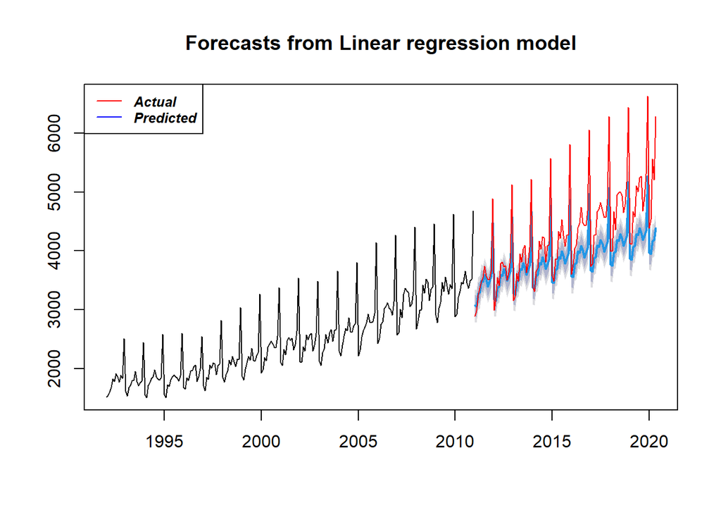

```r
#Construct the long-horizon prediction into the test data set
#This is over 113 periods beyond the test set data
#Plot the prediction along with the test set data
reg_fcast=forecast(reg_bwl,h=113)
plot(reg_fcast,ylim=c(min(bwl),max(bwl)))
lines(bwl_test,col="red")
legend("topleft", legend=c("Actual","Predicted"),
       col=c("red","blue"), lty=1, cex=0.8,text.font=4)
```

As expected, the BWL series exhibit positive trend, with the model indicating an estimated growth of USD8.26million per month. The seasonal estimates are relative to the first month of the year.

The predictive plot clearly indicates the steadily increasing trend and fixed seasonality variation. Compared to the actual test data in red, it is clear here that for long horizon forecast the trend estimate is too conservative, and the seasonal variation is fixed over time.

One alternative of the regression model that might lead to an improvement is to consider modelling the time series in (natural) log transformation. By construction, the time series is now assumed to exhibit proportional growth, with the coefficient associated with the trend indicating the proportional growth per time period.

```r
#Fit the model with log of the time series
lreg_bwl=tslm(log(bwl_train)~trend+season)
summary(lreg_bwl)
```

```
##
## Call:
## tslm(formula = log(bwl_train) ~ trend + season)
##
## Residuals:
##       Min        1Q    Median        3Q       Max
## -0.090182 -0.022647 -0.000931  0.021117  0.108315
##
## Coefficients:
##               Estimate Std. Error t value Pr(>|t|)
## (Intercept)  7.257e+00  9.156e-03 792.602  < 2e-16 ***
## trend        3.325e-03  3.627e-05  91.659  < 2e-16 ***
## season2     -1.383e-02  1.168e-02  -1.184    0.238
## season3      8.242e-02  1.168e-02   7.057 2.31e-11 ***
## season4      8.937e-02  1.168e-02   7.652 6.59e-13 ***
## season5      1.680e-01  1.168e-02  14.385  < 2e-16 ***
## season6      1.559e-01  1.168e-02  13.347  < 2e-16 ***
## season7      2.013e-01  1.168e-02  17.236  < 2e-16 ***
## season8      1.671e-01  1.168e-02  14.305  < 2e-16 ***
## season9      1.128e-01  1.168e-02   9.654  < 2e-16 ***
## season10     1.414e-01  1.168e-02  12.104  < 2e-16 ***
## season11     1.706e-01  1.168e-02  14.597  < 2e-16 ***
## season12     4.763e-01  1.169e-02  40.756  < 2e-16 ***
## ---
## Signif. codes:  0 '***' 0.001 '**' 0.01 '*' 0.05 '.' 0.1 ' ' 1
##
## Residual standard error: 0.036 on 215 degrees of freedom
## Multiple R-squared:  0.9813, Adjusted R-squared:  0.9802
## F-statistic: 938.9 on 12 and 215 DF,  p-value: < 2.2e-16
```

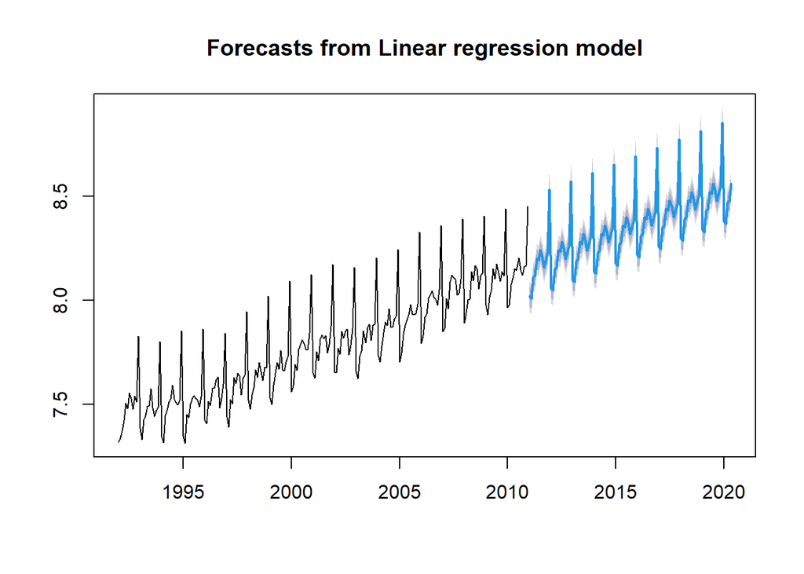

```r
#Predict and plot
lreg_fcast=forecast(lreg_bwl,h=113)
#Remember that you constructed the prediction in log terms!
plot(lreg_fcast)
```

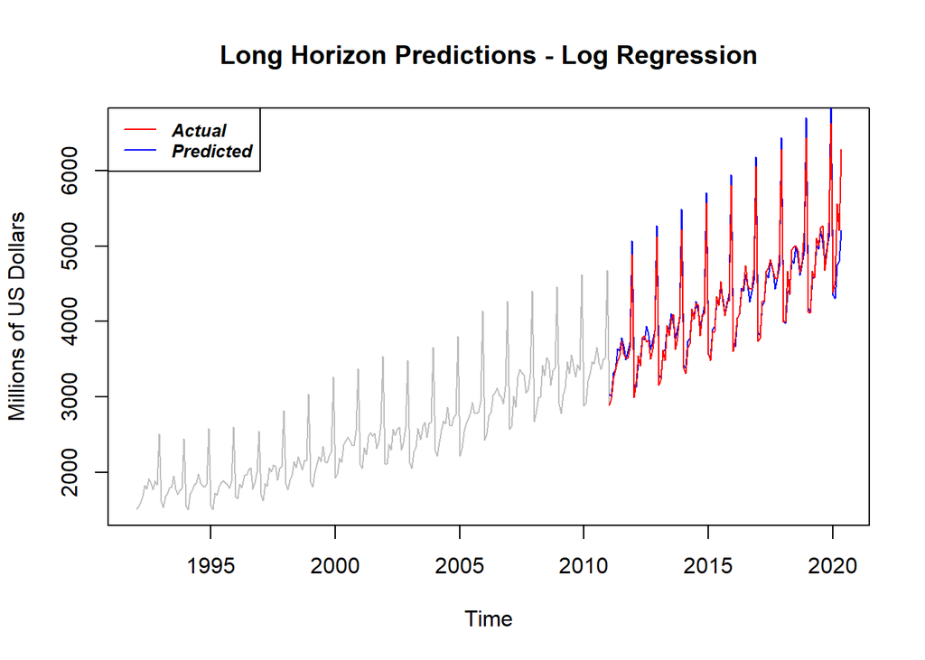

```r
#So you will need to convert the predictions back using the exp() function
plot(bwl,col="gray",main="Long Horizon Predictions - Log Regression",
     ylab="Millions of US Dollars")
lines(exp(lreg_fcast$mean),col="blue")
lines(bwl_test,col="red")
legend("topleft", legend=c("Actual","Predicted"),
       col=c("red","blue"), lty=1, cex=0.8,text.font=4)
```

The log regression model indicates a 0.332% growth per month on average, or 3.99% per annum. Note that all seasonality factors here are also in proportional variation.

Since this model is constructed on the log transformation of the data, its predictions are also in log unit. To make the predictions comparable, these predictions need to be translated back to the same unit as the data using the exponential function.

The plot of the prediction shows that the long horizon predictions from this specification tracks the test data much better than the linear time series regression.

### Exponential Smoothing

The exponential smoothing technique is data driven, and without parametric specifications for each component. It requires assumption on *how* the trend, seasonality and the error term are related (i.e. additive or multiplicative), but uses the data to drive the evolution of each component.

```r
#Fitting the ETS model to training data
#Specification will be chosen automatically using a designated model selection criteria
ets_bwl=ets(bwl_train)
summary(ets_bwl)
```

```
## ETS(M,Ad,M)
##
## Call:
##  ets(y = bwl_train)
##
##   Smoothing parameters:
##     alpha = 0.3308
##     beta  = 0.0193
##     gamma = 1e-04
##     phi   = 0.9787
##
##   Initial states:
##     l = 1810.4955
##     b = 0.2527
##     s = 1.3842 1.0173 0.9892 0.961 1.0157 1.0498
##            1.0033 1.015 0.937 0.9297 0.8425 0.8554
##
##   sigma:  0.0268
##
##      AIC     AICc      BIC
## 3153.206 3156.479 3214.934
##
## Training set error measures:
##                    ME    RMSE      MAE       MPE     MAPE      MASE       ACF1
## Training set 6.374925 64.8597 52.75826 0.2227789 2.140185 0.4952966 -0.1999098
```

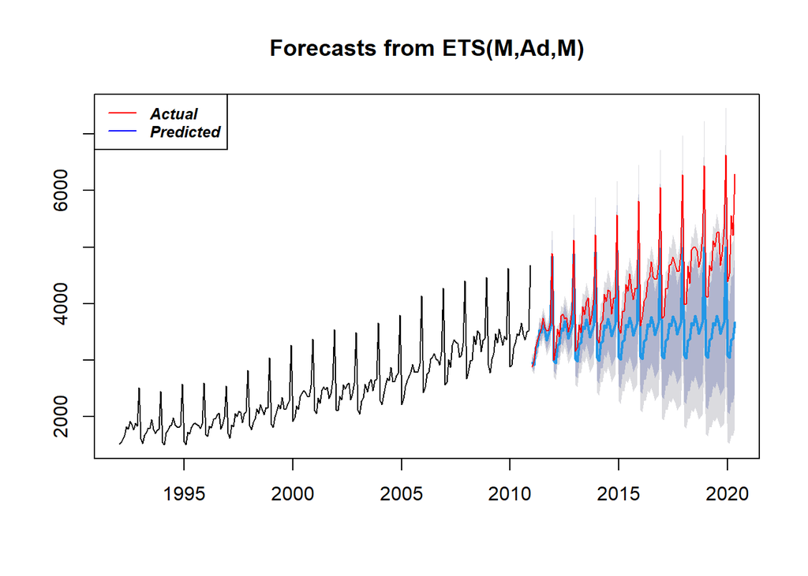

```r
#Prediction still makes use of the forecast() function
ets_fcast=forecast(ets_bwl,h=113)
plot(ets_fcast)
lines(bwl_test,col="red")
legend("topleft", legend=c("Actual","Predicted"),
       col=c("red","blue"), lty=1, cex=0.8,text.font=4)
```

The automatic selection gives the ETS(M,Ad,M) as the model of choice over the training data. This model has the following features:

- Multiplicative error
- Additive dampened trend
- Multiplicative seasonality

The long horizon forecast reveals the flaw of this method, which is that it often performs poorly over the long horizon prediction. The prediction flattens out over the test set, but the test set follows a strong positive trend.

### ARIMA Predictions

The next class of model that can be used is the ARIMA model. The auto.arima() function selects the best fit model. Note that this function explores several alternative models using a logical algorithm, and it can take a while to run particularly if your data set is large.

```r
#Fit the ARIMA model to the training data
#The auto.arima() function searches for the best combination of (p,d,q)(P,D,Q) order
arima_bwl=auto.arima(bwl_train)
arima_bwl
```

```
## Series: bwl_train
## ARIMA(2,1,0)(0,1,2)[12]
##
## Coefficients:
##           ar1      ar2     sma1     sma2
##       -0.8531  -0.5054  -0.2681  -0.1042
## s.e.   0.0608   0.0625   0.0699   0.0656
##
## sigma^2 estimated as 4939:  log likelihood=-1218.51
## AIC=2447.03   AICc=2447.32   BIC=2463.88
```

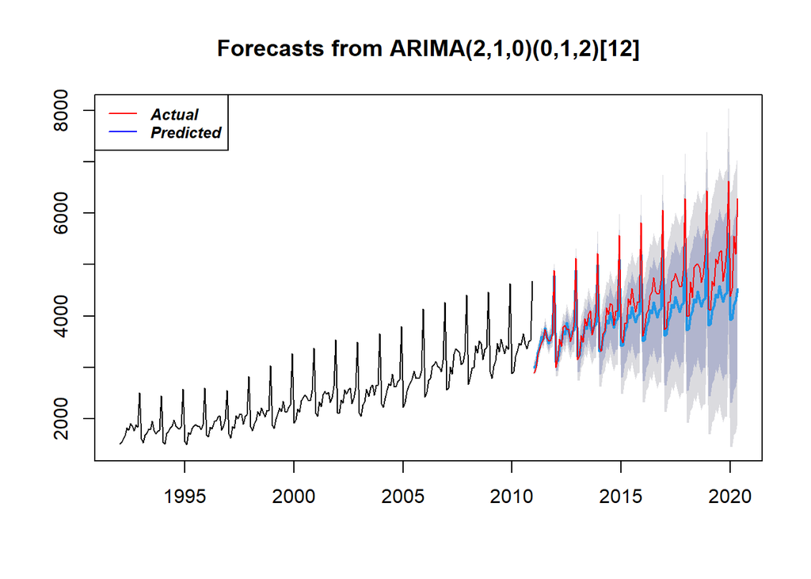

```r
#The forecast() function can be used to generate ARIMA predictions
arima_fcast=forecast(arima_bwl,h=113)
plot(arima_fcast)
lines(bwl_test,col="red")
legend("topleft", legend=c("Actual","Predicted"),
       col=c("red","blue"), lty=1, cex=0.8,text.font=4)
```

The automatic selection chooses the ARIMA(2,1,0)(0,1,2)[12]. The predictions, as you can see tracks the test set data relatively well in the first few years of the test set, but starts to deviate as we move into the longer horizon.

### Accuracy over long horizon predictions

The plots of the predictions depict the direction of the forecasts, and whether it tracks the test data. However, it does not give us a picture of which method is most accurate. Thus, we need to compute the accuracy metrics to assess the accuracy of the predictions over the long horizon.

```r
stats_long=rbind(tsaccuracy(bwl_test,reg_fcast$mean),
                 tsaccuracy(bwl_test,exp(lreg_fcast$mean)),
                  tsaccuracy(bwl_test,ets_fcast$mean),
                  tsaccuracy(bwl_test,arima_fcast$mean))
rownames(stats_long)=c("Regression", "Log Regression","Exp Smoothing", "ARIMA")
stats_long
```

```
##                    RMSE      MAE      MAPE      MASE       ACF
## Regression     541.1879 411.9115  8.641578 2.0098098 0.5094489
## Log Regression 172.4834 106.0776  2.345007 0.5175768 0.2743723
## Exp Smoothing  898.0061 731.7704 15.913623 3.5704738 0.8654311
## ARIMA          442.9746 325.7463  6.835332 1.5893903 0.6173176
```

In terms of the ACF, all models suffer from the issue of correlated errors over time. The exponential smoothing is particularly bad, with autocorrelation of 0.87. This indicate that the prediction error from one period to the next is highly predictable. The log regression produces ACF that is closest to zero, and thus is preferred among the four competing methods here.

## Real Time Predictions

Would the model ranking change if we are to consider real time predictions? That is, when a new data point becomes available, we update both our model and our predictions.

The design of the predictive assessment needs to be thought through carefully. Since the predictions are updated every time a new observation comes in, the process will be more computationally intensive. Unfortunately, there are no automatic functions that would do this in R, as we have to work through the logic of the prediction updating on a case by case basis. In the block of code below,we do the following:

1. Create storage spaces for the predictions that we are going to generate over the test set. There will be one storage matrix for each model.
2. Construct a for loop to:
   1. Update the model parameters at each time point
   2. Construct a one period ahead prediction ($h=1$) for each model
   3. Extract out the prediction and store it in the relevant matrix
   4. Expand the training set data for the following time point
3. Plot the predictions against the observed data.
4. Compute the accuracy metrics for each model.

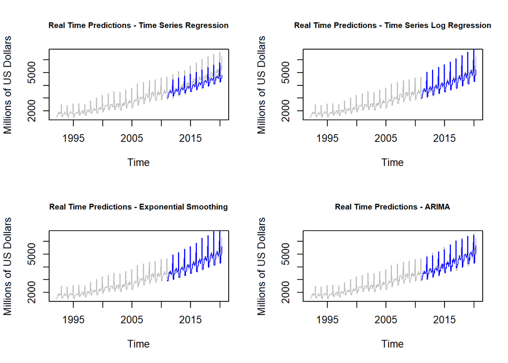

```r
#Storage spaces
ntrain=length(bwl_train)
ntest=length(bwl_test)
training=ts(bwl[1:ntrain],start=c(1992,1),frequency=12)
reg_yhat=matrix(0,ntest,1)
lreg_yhat=matrix(0,ntest,1)
ets_yhat=matrix(0,ntest,1)
arima_yhat=matrix(0,ntest,1)

##This loop is a real time updating loop
##It can take a little while to run
for(i in 1:ntest){
  #Estimate the models
  reg_bwl=tslm(training~trend+season)
  lreg_bwl=tslm(log(training)~trend+season)
  ets_bwl=ets(training,model="MAM",damped=TRUE)
  arima_bwl=Arima(training,order=c(2,1,0),seasonal=c(0,1,2))

  #Predict one period ahead
  reg_f=forecast(reg_bwl,h=1)
  lreg_f=forecast(lreg_bwl,h=1)
  ets_f=forecast(ets_bwl,h=1)
  arima_f=forecast(arima_bwl,h=1)

  #Save the predictions
  reg_yhat[i]=reg_f$mean[1]
  lreg_yhat[i]=exp(lreg_f$mean[1])
  ets_yhat[i]=ets_f$mean[1]
  arima_yhat[i]=arima_f$mean[1]

  #Expand the training set for the next iteration
  training=ts(bwl[1:(ntrain+i)],start=c(1992,1),frequency=12)
}

#Plot the forecasts
par(mfrow=c(2,2))
plot(bwl,col="gray",main="Real Time Predictions - Time Series Regression",
     ylab="Millions of US Dollars",cex.main=0.8)
lines(ts(reg_yhat,start=c(2011,1),frequency=12),col="blue")
plot(bwl,col="gray",main="Real Time Predictions - Time Series Log Regression",
     ylab="Millions of US Dollars",cex.main=0.8)
lines(ts(lreg_yhat,start=c(2011,1),frequency=12),col="blue")
plot(bwl,col="gray",main="Real Time Predictions - Exponential Smoothing",
     ylab="Millions of US Dollars",cex.main=0.8)
lines(ts(ets_yhat,start=c(2011,1),frequency=12),col="blue")
plot(bwl,col="gray",main="Real Time Predictions - ARIMA",
     ylab="Millions of US Dollars",cex.main=0.8)
lines(ts(arima_yhat,start=c(2011,1),frequency=12),col="blue")
```

```r
#A summary of the real time predictive accuracy metrics
stats_short=rbind(tsaccuracy(bwl_test,reg_yhat),
                  tsaccuracy(bwl_test,lreg_yhat),
                  tsaccuracy(bwl_test,ets_yhat),
                  tsaccuracy(bwl_test,arima_yhat))
rownames(stats_short)=c("Regression", "Log Regression","Exp Smoothing", "ARIMA")
stats_short
```

```
##                    RMSE       MAE     MAPE      MASE          ACF
## Regression     363.9856 270.17730 5.687567 1.3182564  0.282445206
## Log Regression 169.0692 103.58533 2.289163 0.5054164  0.286110120
## Exp Smoothing  144.0295  96.74502 2.149683 0.4720409 -0.003490288
## ARIMA          130.3766  94.00831 2.183458 0.4586879  0.186550152
```

The relative ranking of the models are also different in the real time prediction, with the ARIMA model preferred according to the RMSE, MAE and MASE. The exponential smoothing method is preferred according to the MAPE and the autocorrelation of the prediction error. All models generate considerable improvements over the naive prediction, except for the linear regression model.

**This difference in the model ranking highlights the fact that the predictive assessment process needs to be conducted according to the use of the predictive process. The user specific loss can also be brought into the predictive assessment process to aid the model selection for a particular contextual use.**